# CNN-new

## Data and Libraries Loading

### Importing Necessary Libraries

```python
import numpy as np
import pandas as pd
import matplotlib.pyplot as plt
from scipy import stats
import seaborn as sns
import tensorflow as tf
from sklearn.preprocessing import LabelEncoder
from tensorflow.keras.models import Sequential
from tensorflow.keras.layers import Dense, Dropout, Flatten, Conv2D, MaxPool2D
from tensorflow.keras.optimizers import RMSprop
from tensorflow.keras.preprocessing.image import ImageDataGenerator
from sklearn.metrics import confusion_matrix
import keras
```

### Loading Data

```python
train_data = pd.read_csv('./data/csvTrainImages 13440x1024.csv', header = None)
train_label = pd.read_csv('./data/csvTrainLabel 13440x1.csv', header = None)
test_data = pd.read_csv('./data/csvTestImages 3360x1024.csv', header = None)
test_label = pd.read_csv('./data/csvTestLabel 3360x1.csv', header = None)
```

### Convert Labels to one dimension

```python
train_data = train_data.iloc[:,:].values.astype('float32')
train_label = train_label.iloc[:,:].values.astype('int32')-1
test_data = test_data.iloc[:,:].values.astype('float32')
test_label = test_label.iloc[:,:].values.astype('int32')-1
```

### Checking dimensions

```python
pd.DataFrame(train_label).head(25)
```

|  | 0 |
| --- | --- |
| 0 | 0 |
| 1 | 0 |
| 2 | 0 |
| 3 | 0 |
| 4 | 0 |
| 5 | 0 |
| 6 | 0 |
| 7 | 0 |
| 8 | 1 |
| 9 | 1 |
| 10 | 1 |
| 11 | 1 |
| 12 | 1 |
| 13 | 1 |
| 14 | 1 |
| 15 | 1 |
| 16 | 2 |
| 17 | 2 |
| 18 | 2 |
| 19 | 2 |
| 20 | 2 |
| 21 | 2 |
| 22 | 2 |
| 23 | 2 |
| 24 | 3 |

### Checking data type of labels

```python
pd.DataFrame(train_label).info()
```

```
<class 'pandas.core.frame.DataFrame'>
RangeIndex: 13440 entries, 0 to 13439
Data columns (total 1 columns):
0    13440 non-null int32
dtypes: int32(1)
memory usage: 52.6 KB
```

### Visualizing some letters

```python
def row_calculator(number_of_images, number_of_columns):
    if number_of_images % number_of_columns != 0:
        return (number_of_images / number_of_columns)+1
    else:
        return (number_of_images / number_of_columns)


def display_image(x, img_size, number_of_images):
    plt.figure(figsize = (8, 7))
    if x.shape[0] > 0:
        n_samples = int(x.shape[0]/4)
        x = x.reshape(n_samples, img_size, img_size)
        number_of_rows = row_calculator(number_of_images, 4)
        for i in range(number_of_images):
            plt.subplot(number_of_rows, 4, i+1)
            plt.imshow(x[i], cmap='gray')
```

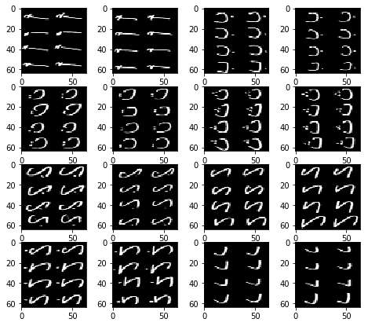

```python
display_image(train_data, 64,16)
plt.show()
```

We notice how these 8 letters are wirtten in very different ways because different people have written them

## Data Reshaping

### Encode labels as categories instead of integers

```python
labelencoder_X = LabelEncoder()
train_label = labelencoder_X.fit_transform(train_label)
```

```python
train_data.shape
```

```
(13440, 1024)
```

The shape of the data now is (13440, 1024) so we wanna reshape it to demonstrate 32x32 pixels shape for each of the 13440 images

```python
train_data = train_data.reshape([-1, 32, 32, 1])
test_data = test_data.reshape([-1, 32, 32, 1])
```

```python
train_data.shape
```

```
(13440, 32, 32, 1)
```

Now it's in the right shape to be able to pass it to the CNN

### Make labels as categories

```python
train_label =keras.utils.np_utils.to_categorical(train_label,28)

test_label =keras.utils.np_utils.to_categorical(test_label,28)

train_label_data = pd.DataFrame(train_label)
```

```python
train_label_data.head()
train_label.shape
```

```
(13440, 28)
```

28 columns --> 28 categories --> 28 letters Each letter is a column with a binary labeling

```python
print(train_label_data[train_label_data[0]==1].count())
```

```
0     480
1     480
2     480
3     480
4     480
5     480
6     480
7     480
8     480
9     480
10    480
11    480
12    480
13    480
14    480
15    480
16    480
17    480
18    480
19    480
20    480
21    480
22    480
23    480
24    480
25    480
26    480
27    480
dtype: int64
```

Each of the 28 letters written 480 times in the training data, giving us a total of 13,440 training cases

## Data Preprocessing

### Data Augmentation: Rescaling pixels and Adding some rotation

```python
datagen = ImageDataGenerator(rescale=1.0/255.0,
        featurewise_center=False,
        samplewise_center=False,
        featurewise_std_normalization=False,
        samplewise_std_normalization=False,
        zca_whitening=False,
        rotation_range=10,
        zoom_range = 0.1,
        width_shift_range=0.1,
        height_shift_range=0.1,
        horizontal_flip=False,
        vertical_flip=False)
```

```python
train_iterator = datagen.flow(train_data, train_label, batch_size=64)
test_iterator = datagen.flow(test_data, test_label, batch_size=64)
print('Batches train=%d, test=%d' % (len(train_iterator), len(test_iterator)))

batchX, batchy = train_iterator.next()
print('Batch shape=%s, min=%.3f, max=%.3f' % (batchX.shape, batchX.min(), batchX.max()))
```

```
Batches train=210, test=53
Batch shape=(64, 32, 32, 1), min=0.000, max=1.000
```

Data pixels were rescaled from 1 to 0 for processing in the convolutional neural network We add some rotation to allow the network to recognize the letters even if they're not placed in the middle of the sheet

## Model

```python
recognizer = Sequential()
recognizer.add(Conv2D(filters = 32, kernel_size = (5,5),padding = 'Same',
                 activation ='relu', input_shape = (32,32,1)))
recognizer.add(Conv2D(filters = 32, kernel_size = (5,5),padding = 'Same',
                 activation ='relu'))
recognizer.add(MaxPool2D(pool_size=(2,2)))
recognizer.add(Dropout(0.5))


recognizer.add(Conv2D(filters = 64, kernel_size = (3,3),padding = 'Same',
                 activation ='relu'))
recognizer.add(Conv2D(filters = 64, kernel_size = (3,3),padding = 'Same',
                 activation ='relu'))
recognizer.add(MaxPool2D(pool_size=(2,2), strides=(2,2)))
recognizer.add(Dropout(0.5))

recognizer.add(Flatten())
recognizer.add(Dense(units = 256, input_dim = 1024, activation = 'relu'))
recognizer.add(Dense(units = 256, activation = "relu"))
recognizer.add(Dropout(0.5))
recognizer.add(Dense(28, activation = "softmax"))
```

```python
recognizer.summary()
```

```
Model: "sequential_2"
_________________________________________________________________
Layer (type)                 Output Shape              Param #
=================================================================
conv2d_8 (Conv2D)            (None, 32, 32, 32)        832
_________________________________________________________________
conv2d_9 (Conv2D)            (None, 32, 32, 32)        25632
_________________________________________________________________
max_pooling2d_4 (MaxPooling2 (None, 16, 16, 32)        0
_________________________________________________________________
dropout_6 (Dropout)          (None, 16, 16, 32)        0
_________________________________________________________________
conv2d_10 (Conv2D)           (None, 16, 16, 64)        18496
_________________________________________________________________
conv2d_11 (Conv2D)           (None, 16, 16, 64)        36928
_________________________________________________________________
max_pooling2d_5 (MaxPooling2 (None, 8, 8, 64)          0
_________________________________________________________________
dropout_7 (Dropout)          (None, 8, 8, 64)          0
_________________________________________________________________
flatten_2 (Flatten)          (None, 4096)              0
_________________________________________________________________
dense_6 (Dense)              (None, 256)               1048832
_________________________________________________________________
dense_7 (Dense)              (None, 256)               65792
_________________________________________________________________
dropout_8 (Dropout)          (None, 256)               0
_________________________________________________________________
dense_8 (Dense)              (None, 28)                7196
=================================================================
Total params: 1,203,708
Trainable params: 1,203,708
Non-trainable params: 0
_________________________________________________________________
```

Define optimizer, using RMSprop

```python
optimizer = RMSprop(lr=0.001, rho=0.9, epsilon=1e-08, decay=0.0)
```

Compiling Model

```python
recognizer.compile(optimizer = optimizer , loss = "categorical_crossentropy", metrics=["accuracy"])
```

Fit the model to the training data for 30 epochs

```python
recognizer.fit_generator(train_iterator,epochs = 30, verbose = 2, steps_per_epoch=train_data.shape[0] // 100)
```

[output not shown]

```
Train for 134 steps
134/134 - 5s - loss: 2.8895 - accuracy: 0.1444
134/134 - 4s - loss: 1.9409 - accuracy: 0.3624
134/134 - 4s - loss: 1.4168 - accuracy: 0.5191
134/134 - 4s - loss: 1.0986 - accuracy: 0.6199
134/134 - 3s - loss: 0.9063 - accuracy: 0.6930
134/134 - 3s - loss: 0.7498 - accuracy: 0.7480
134/134 - 3s - loss: 0.6527 - accuracy: 0.7810
134/134 - 4s - loss: 0.5894 - accuracy: 0.8055
134/134 - 4s - loss: 0.5307 - accuracy: 0.8268
134/134 - 4s - loss: 0.4717 - accuracy: 0.8439
134/134 - 4s - loss: 0.4372 - accuracy: 0.8617
134/134 - 4s - loss: 0.4098 - accuracy: 0.8689
134/134 - 4s - loss: 0.3761 - accuracy: 0.8825
134/134 - 4s - loss: 0.3617 - accuracy: 0.8801
134/134 - 3s - loss: 0.3443 - accuracy: 0.8912
134/134 - 4s - loss: 0.3302 - accuracy: 0.8998
134/134 - 4s - loss: 0.3164 - accuracy: 0.9002
134/134 - 3s - loss: 0.3019 - accuracy: 0.9051
134/134 - 3s - loss: 0.2893 - accuracy: 0.9101
134/134 - 3s - loss: 0.2910 - accuracy: 0.9128
134/134 - 3s - loss: 0.2753 - accuracy: 0.9158
134/134 - 4s - loss: 0.2790 - accuracy: 0.9142
134/134 - 4s - loss: 0.2415 - accuracy: 0.9254
134/134 - 4s - loss: 0.2471 - accuracy: 0.9220
134/134 - 4s - loss: 0.2426 - accuracy: 0.9257
134/134 - 3s - loss: 0.2457 - accuracy: 0.9258
134/134 - 4s - loss: 0.2420 - accuracy: 0.9268
134/134 - 4s - loss: 0.2595 - accuracy: 0.9249
134/134 - 4s - loss: 0.2262 - accuracy: 0.9320
134/134 - 3s - loss: 0.2310 - accuracy: 0.9310
```

```
<tensorflow.python.keras.callbacks.History at 0x7fbd3449ea90>
```

The model accuracy is 93.2% on the training data by the 30th epoch

Checking model performance against test set by taking the average of 10 runs on the test set

```python
test_acc1=[]
for i in range(10):
    _, acc = recognizer.evaluate_generator(test_iterator, steps=len(test_iterator))
    print('Test Accuracy {0}: {1}' .format(i+1 , np.round((acc * 100),2)))
    test_acc1.append(acc * 100)
```

[output not shown]

```
Test Accuracy 1: 93.39
```

[output not shown]

```
Test Accuracy 2: 93.75
```

[output not shown]

```
Test Accuracy 3: 93.87
```

[output not shown]

```
Test Accuracy 4: 93.75
```

[output not shown]

```
Test Accuracy 5: 93.66
```

[output not shown]

```
Test Accuracy 6: 94.17
```

[output not shown]

```
Test Accuracy 7: 94.14
```

[output not shown]

```
Test Accuracy 8: 94.38
```

[output not shown]

```
Test Accuracy 9: 93.63
Test Accuracy 10: 93.84
```

```python
basic_code_results = pd.Series(test_acc1)
np.round((basic_code_results.mean()),2)
```

```
93.86
```

Make some improvement

### Modifying some layers

modify drop out parameter: in our model, we drop out 0.5 of the input nodes in all layers, but this may lead to relatively weak performance, on other words "Under fitting‟. So we will modify it in the 2 drop out layers that deal with image data before being flattened to produce probability of each of the 28 letters.

```python
recognizer2 = Sequential()

recognizer2.add(Conv2D(filters = 32, kernel_size = (5,5),padding = 'Same',
                 activation ='relu', input_shape = (32,32,1)))
recognizer2.add(Conv2D(filters = 32, kernel_size = (5,5),padding = 'Same',
                 activation ='relu'))
recognizer2.add(MaxPool2D(pool_size=(2,2)))
recognizer2.add(Dropout(0.2))

recognizer2.add(Conv2D(filters = 64, kernel_size = (3,3),padding = 'Same',
                 activation ='relu'))
recognizer2.add(Conv2D(filters = 64, kernel_size = (3,3),padding = 'Same',
                 activation ='relu'))
recognizer2.add(MaxPool2D(pool_size=(2,2), strides=(2,2)))
recognizer2.add(Dropout(0.2))


recognizer2.add(Flatten())
recognizer2.add(Dense(units = 256, input_dim = 1024, activation = 'relu'))
recognizer2.add(Dense(units = 256, activation = "relu"))
recognizer2.add(Dropout(0.5))
recognizer2.add(Dense(28, activation = "softmax"))
```

```python
recognizer2.compile(optimizer = optimizer , loss = "categorical_crossentropy", metrics=["accuracy"])
```

```python
recognizer2.summary()
```

```
Model: "sequential_3"
_________________________________________________________________
Layer (type)                 Output Shape              Param #
=================================================================
conv2d_12 (Conv2D)           (None, 32, 32, 32)        832
_________________________________________________________________
conv2d_13 (Conv2D)           (None, 32, 32, 32)        25632
_________________________________________________________________
max_pooling2d_6 (MaxPooling2 (None, 16, 16, 32)        0
_________________________________________________________________
dropout_9 (Dropout)          (None, 16, 16, 32)        0
_________________________________________________________________
conv2d_14 (Conv2D)           (None, 16, 16, 64)        18496
_________________________________________________________________
conv2d_15 (Conv2D)           (None, 16, 16, 64)        36928
_________________________________________________________________
max_pooling2d_7 (MaxPooling2 (None, 8, 8, 64)          0
_________________________________________________________________
dropout_10 (Dropout)         (None, 8, 8, 64)          0
_________________________________________________________________
flatten_3 (Flatten)          (None, 4096)              0
_________________________________________________________________
dense_9 (Dense)              (None, 256)               1048832
_________________________________________________________________
dense_10 (Dense)             (None, 256)               65792
_________________________________________________________________
dropout_11 (Dropout)         (None, 256)               0
_________________________________________________________________
dense_11 (Dense)             (None, 28)                7196
=================================================================
Total params: 1,203,708
Trainable params: 1,203,708
Non-trainable params: 0
_________________________________________________________________
```

```python
recognizer2.fit_generator(train_iterator,epochs = 30, verbose = 2, steps_per_epoch=train_data.shape[0] // 100)
```

[output not shown]

```
Train for 134 steps
134/134 - 4s - loss: 2.6746 - accuracy: 0.1958
134/134 - 4s - loss: 1.6002 - accuracy: 0.4674
134/134 - 4s - loss: 1.1407 - accuracy: 0.6066
134/134 - 4s - loss: 0.8966 - accuracy: 0.6967
134/134 - 4s - loss: 0.7199 - accuracy: 0.7622
134/134 - 4s - loss: 0.5873 - accuracy: 0.8022
134/134 - 4s - loss: 0.5057 - accuracy: 0.8370
134/134 - 4s - loss: 0.4382 - accuracy: 0.8589
134/134 - 4s - loss: 0.3953 - accuracy: 0.8747
134/134 - 4s - loss: 0.3556 - accuracy: 0.8875
134/134 - 3s - loss: 0.3201 - accuracy: 0.8993
134/134 - 4s - loss: 0.3077 - accuracy: 0.9032
134/134 - 3s - loss: 0.2823 - accuracy: 0.9107
134/134 - 4s - loss: 0.2443 - accuracy: 0.9241
134/134 - 4s - loss: 0.2602 - accuracy: 0.9179
134/134 - 4s - loss: 0.2237 - accuracy: 0.9283
134/134 - 4s - loss: 0.2220 - accuracy: 0.9298
134/134 - 4s - loss: 0.2007 - accuracy: 0.9390
134/134 - 4s - loss: 0.2182 - accuracy: 0.9331
134/134 - 4s - loss: 0.1982 - accuracy: 0.9376
134/134 - 4s - loss: 0.1988 - accuracy: 0.9388
134/134 - 3s - loss: 0.1877 - accuracy: 0.9444
134/134 - 3s - loss: 0.1756 - accuracy: 0.9476
134/134 - 4s - loss: 0.1726 - accuracy: 0.9468
134/134 - 3s - loss: 0.1620 - accuracy: 0.9524
134/134 - 4s - loss: 0.1763 - accuracy: 0.9469
134/134 - 4s - loss: 0.1668 - accuracy: 0.9501
134/134 - 4s - loss: 0.1600 - accuracy: 0.9541
134/134 - 4s - loss: 0.1598 - accuracy: 0.9549
134/134 - 4s - loss: 0.1566 - accuracy: 0.9537
```

```
<tensorflow.python.keras.callbacks.History at 0x7fbd640af2b0>
```

Result is better with 95.5% accuracy on train

Check performance on test

```python
test_acc2 = []
for i in range(10):
    _, acc = recognizer2.evaluate_generator(test_iterator, steps=len(test_iterator))
    print('Test Accuracy {0}: {1}' .format(i+1 , np.round((acc * 100),2)))
    test_acc2.append(np.round((acc * 100),2))
```

[output not shown]

```
Test Accuracy 1: 95.06
```

[output not shown]

```
Test Accuracy 2: 95.39
```

[output not shown]

```
Test Accuracy 3: 94.94
```

[output not shown]

```
Test Accuracy 4: 95.15
```

[output not shown]

```
Test Accuracy 5: 95.21
```

[output not shown]

```
Test Accuracy 6: 95.89
```

[output not shown]

```
Test Accuracy 7: 95.42
```

[output not shown]

```
Test Accuracy 8: 95.6
```

[output not shown]

```
Test Accuracy 9: 95.06
Test Accuracy 10: 95.54
```

```python
final_code_results=pd.Series(test_acc2)
np.round((final_code_results.mean()),2)
```

```
95.33
```

## Predictions and Results

### Looking at misclassified characters

```python
test_predictions = recognizer2.predict(test_data)
test_predictions = np.round(test_predictions)
test_predictions1=pd.DataFrame(test_predictions)
test_predictions1.head()
```

|  | 0 | 1 | 2 | 3 | 4 | 5 | 6 | 7 | 8 | 9 | ... | 18 | 19 | 20 | 21 | 22 | 23 | 24 | 25 | 26 | 27 |
| --- | --- | --- | --- | --- | --- | --- | --- | --- | --- | --- | --- | --- | --- | --- | --- | --- | --- | --- | --- | --- | --- |
| 0 | 1.0 | 0.0 | 0.0 | 0.0 | 0.0 | 0.0 | 0.0 | 0.0 | 0.0 | 0.0 | ... | 0.0 | 0.0 | 0.0 | 0.0 | 0.0 | 0.0 | 0.0 | 0.0 | 0.0 | 0.0 |
| 1 | 1.0 | 0.0 | 0.0 | 0.0 | 0.0 | 0.0 | 0.0 | 0.0 | 0.0 | 0.0 | ... | 0.0 | 0.0 | 0.0 | 0.0 | 0.0 | 0.0 | 0.0 | 0.0 | 0.0 | 0.0 |
| 2 | 0.0 | 0.0 | 0.0 | 0.0 | 0.0 | 0.0 | 0.0 | 0.0 | 0.0 | 0.0 | ... | 0.0 | 0.0 | 0.0 | 0.0 | 0.0 | 0.0 | 1.0 | 0.0 | 0.0 | 0.0 |
| 3 | 0.0 | 0.0 | 0.0 | 0.0 | 0.0 | 0.0 | 0.0 | 0.0 | 0.0 | 0.0 | ... | 0.0 | 0.0 | 0.0 | 0.0 | 0.0 | 0.0 | 0.0 | 0.0 | 0.0 | 1.0 |
| 4 | 0.0 | 0.0 | 1.0 | 0.0 | 0.0 | 0.0 | 0.0 | 0.0 | 0.0 | 0.0 | ... | 0.0 | 0.0 | 0.0 | 0.0 | 0.0 | 0.0 | 0.0 | 0.0 | 0.0 | 0.0 |

5 rows × 28 columns

```python
test_label1=pd.DataFrame(test_label)
```

Getting the wrongly classified images by taking the character that had the largest probability for each image

```python
incorrect_label_indices= (test_predictions1.idxmax(axis=1) != test_label1.idxmax(axis=1))
```

```python
misclassified_data=test_data[incorrect_label_indices]
new_labels = test_label1[incorrect_label_indices]
incorrect_prediction = test_predictions1[incorrect_label_indices]
```

```python
len(incorrect_prediction)
```

```
411
```

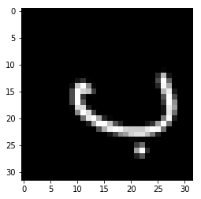

```python
plt.imshow(misclassified_data[0].squeeze().T, cmap='gray')
```

```python
pd.Series(incorrect_prediction.idxmax(axis=1)).reset_index()[0][0]
```

```
24
```

```python
pd.Series(new_labels.idxmax(axis=1)).reset_index()[0][0]
```

```
1
```

Another misclassification

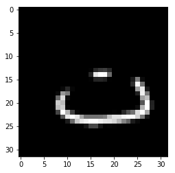

```python
plt.imshow(misclassified_data[200].squeeze().T, cmap='gray')
```

```python
pd.Series(incorrect_prediction.idxmax(axis=1)).reset_index()[0][200]
```

```
2
```

```python
pd.Series(new_labels.idxmax(axis=1)).reset_index()[0][200]
```

```
24
```

```python
import numpy as np
import cv2
import matplotlib.pyplot as plt
from time import time
import keras.backend as K
from keras.preprocessing.image import ImageDataGenerator
from keras.preprocessing import image
from keras.models import Model
from keras.layers import Input, Dense, Dropout
from keras.applications.inception_v3 import InceptionV3
```

```python
import sklearn
report = sklearn.metrics.classification_report(test_label1.idxmax(axis=1), test_predictions1.idxmax(axis=1))
print(report)
```

```
              precision    recall  f1-score   support

           0       1.00      0.95      0.97       120
           1       1.00      0.62      0.76       120
           2       0.76      0.85      0.80       120
           3       0.95      0.63      0.76       120
           4       0.89      0.92      0.90       120
           5       0.80      0.98      0.88       120
           6       0.99      0.90      0.94       120
           7       0.81      0.90      0.85       120
           8       0.91      0.72      0.80       120
           9       0.89      0.93      0.91       120
          10       1.00      0.73      0.85       120
          11       0.95      0.88      0.91       120
          12       0.97      0.92      0.94       120
```

[output cut: 19 more lines]

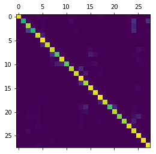

```python
import sklearn.metrics as metrics
confusion_matrix = metrics.confusion_matrix(y_true=test_label1.idxmax(axis=1), y_pred=test_predictions1.idxmax(axis=1))
plt.matshow(confusion_matrix)
```

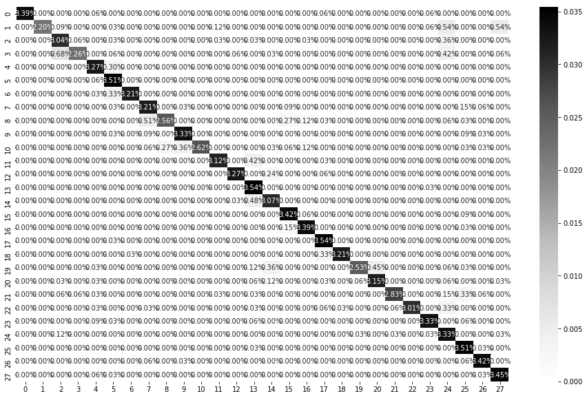

```python
import seaborn as sns
plt.figure(figsize = (16,10))
sns.heatmap(confusion_matrix/np.sum(confusion_matrix), annot=True,
            fmt='.2%', cmap='Greys')
```

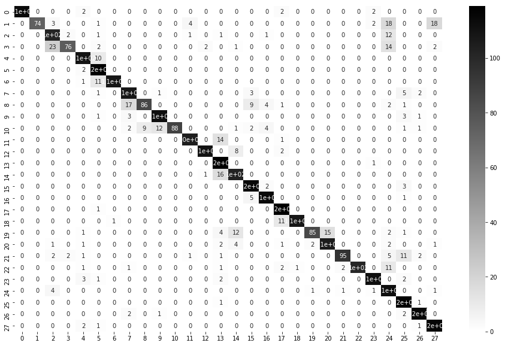

```python
plt.figure(figsize = (16,10))
sns.heatmap(confusion_matrix, annot=True ,cmap='gist_yarg')
```

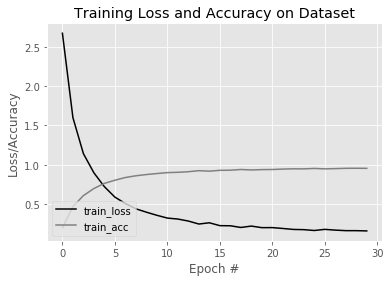

```python
N = 30
plt.style.use("ggplot")
plt.figure()
plt.plot(np.arange(0, N), recognizer2.history.history["loss"], label="train_loss", color="black")
plt.plot(np.arange(0, N), recognizer2.history.history["accuracy"], label="train_acc", color="grey")
plt.title("Training Loss and Accuracy on Dataset")
plt.xlabel("Epoch #")
plt.ylabel("Loss/Accuracy")
plt.legend(loc="lower left")
```

```python
#tf.keras.utils.plot_model(recognizer2, to_file='model_plot.png', show_shapes=True, show_layer_names=True)
```

[output not shown]